# Planning Stage: Data Description & Exploratory Data Analysis and Visualization (individual assignment 1)

Name: Loay Al Abri #84813229  
Group 16

```r
library(tidyverse)
library(tidymodels)
library(Metrics)
library(ggplot2)
library(broom)
library(GGally)
library(gridExtra)
library(cowplot)
```

## Data Description

The dataset used for this project is the GitHub Repositories data from Kaggle that can be accessed here: https://www.kaggle.com/datasets/donbarbos/github-repos/data. The dataset has over $215,000$ observations of top GitHub Repositories by star with over $167$ stars. The data was collected using the GitHub search API.

#### The data set has the following 24 columns:

- `Name` : a categorical variable that represents the name of the GitHub repository.
- `Description`: a text that is brief textual description that summarizes the purpose or focus of the repository.
- `URL`: a text that represents the web address that links to the GitHub repository, which is a unique identifier for the repository.
- `Created At`: date-time of class POSIXct that represents the date and time the repository was created on.
- `Updated At`: date-time of class POSIXct that represents the date and time of the most recent update to the repo.
- `Homepage`: a text that represents the URL to the homepage or landing page associated with the repository, providing additional information or resources.
- `Size`: a continous variable that represents the total size of the repositoy in bytes.
- `Stars`: a continous variable that represents the number of stars or likes that the repository has received from other GitHub users.
- `Forks`: a continous variable that represents the number of times the repository has been forked by other GitHub users.
- `Issues`: a continous variable that represents the total number of open issues.
- `Watchers`: a continous variable that represents the number of GitHub users who are "watching" or monitoring the repository for updates and changes.
- `Language`: a categorical variable that represents the primary programming language of the repository.
- `License`: a categorical variable that represents information about the software license using a license identifier.
- `Topic`: a list of topics or tags associated with the repository, helping users discover related projects and topics of interest.
- `Has Issues`: a categorical variable indicating if the repository has issues or not.
- `Has Projects`: a categorical variable indicating whether the repository uses GitHub Projects to manage and organize tasks and work items.
- `Has Downloads`: a categorical variable indicating whether the repository offers downloadable files or assets to users.
- `Has Wiki`: a categorical variable indicating whether the repository has an associated wiki with additional documentation and information.
- `Has Pages`: a categorical variable indicating whether the repository has GitHub Pages enabled, allowing the creation of a website associated with the repository.
- `Has Discussions`: a categorical variable indicating whether the repository has GitHub Discussions enabled, allowing community discussions and collaboration.
- `Is Fork`: a categorical variable indicating whether the repository is a fork of another repository. In this case, it's false, meaning it is not a fork.
- `Is Archived`: a categorical variable indicating whether the repository is archived. Archived repositories are typically read-only and are no longer actively maintained.
- `Is Template`: a categorical variable indicating whether the repository is set up as a template.
- `Default Branch`: the name of the default branch.

## Research Questions

In this project, the response variable is the `Stars` column, which represents how the number of stars the repository has. The focus of this project is understanding the relationship between Stars and other variables in the dataset. The following questions are of interest:

> What is the relationship between the number of starts a Github and the number of issues, forks, and the size of the repository? Is a linear model appropriate for the data? The dataset include all the information needed to answer this question. A linear model can be fitted using the `Stars` as a response and `Forks`, `Issues`, and `Size` as the covariates, then we can look at the coefficients and their corresponding $p$-values to draw a conclusion about the relationship between them and the response variable.

> What combination of variables are significant in predicting the stars a dataset has? To answer this question, we will use forward selection and backward selection to select the variables that are important in the model. Then, we will construct $2$ linear models, one for the variables gotten from forward selection and one for backward selection, and compare their $R^2$ scores.

## Exploratory Data Analysis and Visualization

### Data Cleaning

We will drop the following columns because they are not relevant to our questions and they represent text data that will make our model complecated `Name`, `Description`, `URL`, `Homepage`, `Topics` and `License`. Also, instead of of having `Created At` and `Updated At`, we will use them to get the age of the repository in days because we expect that an older repository will have more stars in general since it has been on the internet for a long time.

```r
git_rep <- read_csv("data/repositories.csv")
```

```r
git_rep <- git_rep %>%
    mutate(Age = as.integer(difftime(`Updated At`, `Created At`, units = "days"))) %>%
    select(-Name, -Homepage, -URL, -Topics, -License, -Description,-`Created At`, -`Updated At`)
head(git_rep)
```

A tibble: 6 × 17

| Size <dbl> | Stars <dbl> | Forks <dbl> | Issues <dbl> | Watchers <dbl> | Language <chr> | Has Issues <lgl> | Has Projects <lgl> | Has Downloads <lgl> | Has Wiki <lgl> | Has Pages <lgl> | Has Discussions <lgl> | Is Fork <lgl> | Is Archived <lgl> | Is Template <lgl> | Default Branch <chr> | Age <int> |
| --- | --- | --- | --- | --- | --- | --- | --- | --- | --- | --- | --- | --- | --- | --- | --- | --- |
| 387451 | 374074 | 33599 | 248 | 374074 | TypeScript | TRUE | TRUE | TRUE | FALSE | TRUE | FALSE | FALSE | FALSE | FALSE | main | 3192 |
| 17087 | 298393 | 57194 | 46 | 298393 | NA | TRUE | FALSE | TRUE | FALSE | TRUE | FALSE | FALSE | FALSE | FALSE | main | 3632 |
| 1441 | 269997 | 26485 | 61 | 269997 | NA | TRUE | FALSE | TRUE | FALSE | TRUE | FALSE | FALSE | FALSE | FALSE | main | 3358 |
| 187799 | 267901 | 21497 | 16712 | 267901 | NA | FALSE | FALSE | TRUE | FALSE | FALSE | FALSE | FALSE | TRUE | FALSE | master | 1640 |
| 20998 | 265161 | 69434 | 56 | 265161 | NA | TRUE | FALSE | TRUE | FALSE | FALSE | FALSE | FALSE | FALSE | FALSE | main | 2663 |
| 5088 | 256615 | 29254 | 191 | 256615 | Python | TRUE | FALSE | TRUE | FALSE | FALSE | FALSE | FALSE | FALSE | FALSE | master | 2740 |

The Language column contains some missing values. Let's see how many we have in the dataset and deal with them accordingly.

```r
broom::tidy(colSums(is.na(git_rep)))
```

A tibble: 17 × 2

| names <chr> | x <dbl> |
| --- | --- |
| Size | 0 |
| Stars | 0 |
| Forks | 0 |
| Issues | 0 |
| Watchers | 0 |
| Language | 16076 |
| Has Issues | 0 |
| Has Projects | 0 |
| Has Downloads | 0 |
| Has Wiki | 0 |
| Has Pages | 0 |
| Has Discussions | 0 |
| Is Fork | 0 |
| Is Archived | 0 |
| Is Template | 0 |
| Default Branch | 0 |
| Age | 0 |

```r
lang_count <- git_rep %>% count(Language) %>% arrange(desc(n)) %>% head(10)
lang_count %>% head(5)
lang_count %>% tail(5)
```

A tibble: 5 × 2

| Language <chr> | n <int> |
| --- | --- |
| Python | 34331 |
| JavaScript | 31831 |
| NA | 16076 |
| Java | 15298 |
| TypeScript | 11670 |

A tibble: 5 × 2

| Language <chr> | n <int> |
| --- | --- |
| C++ | 11391 |
| Go | 10712 |
| C | 8907 |
| C# | 7295 |
| PHP | 6741 |

The Language column has $16,076$ missing values, which is about $7%$ of the whole dataset. In this situation, it is better to remove the `Language` column becaus it has a lot of missing values and it has a lot of categories that will make our model hard to interpret with many categories haveing only one or a few observation.

```r
git_rep <- git_rep %>%
    select(-Language)
```

```r
git_rep %>% count(`Default Branch`) %>% arrange(desc(n)) %>% head(10)
```

A tibble: 10 × 2

| Default Branch <chr> | n <int> |
| --- | --- |
| master | 162808 |
| main | 41185 |
| develop | 3370 |
| dev | 1248 |
| gh-pages | 832 |
| development | 328 |
| trunk | 224 |
| next | 145 |
| release | 132 |
| devel | 131 |

From the count table above, we see that more than half of the data has "master" as its default branch, and around $20% has main as a default branch. Thus, we can significantly reduce the number of categories in the default branch columns to three categories master, main, and other. This will make the model simpler and more interpretable.

```r
git_rep <- git_rep %>%
    mutate(
        Default_branch = case_when(
            `Default Branch` == "master" ~ "master",
            `Default Branch` == "main" ~ "main",
            TRUE ~ "other"
        )
    ) %>%
    select(-`Default Branch`)
head(git_rep)
```

A tibble: 6 × 16

| Size <dbl> | Stars <dbl> | Forks <dbl> | Issues <dbl> | Watchers <dbl> | Has Issues <lgl> | Has Projects <lgl> | Has Downloads <lgl> | Has Wiki <lgl> | Has Pages <lgl> | Has Discussions <lgl> | Is Fork <lgl> | Is Archived <lgl> | Is Template <lgl> | Age <int> | Default_branch <chr> |
| --- | --- | --- | --- | --- | --- | --- | --- | --- | --- | --- | --- | --- | --- | --- | --- |
| 387451 | 374074 | 33599 | 248 | 374074 | TRUE | TRUE | TRUE | FALSE | TRUE | FALSE | FALSE | FALSE | FALSE | 3192 | main |
| 17087 | 298393 | 57194 | 46 | 298393 | TRUE | FALSE | TRUE | FALSE | TRUE | FALSE | FALSE | FALSE | FALSE | 3632 | main |
| 1441 | 269997 | 26485 | 61 | 269997 | TRUE | FALSE | TRUE | FALSE | TRUE | FALSE | FALSE | FALSE | FALSE | 3358 | main |
| 187799 | 267901 | 21497 | 16712 | 267901 | FALSE | FALSE | TRUE | FALSE | FALSE | FALSE | FALSE | TRUE | FALSE | 1640 | master |
| 20998 | 265161 | 69434 | 56 | 265161 | TRUE | FALSE | TRUE | FALSE | FALSE | FALSE | FALSE | FALSE | FALSE | 2663 | main |
| 5088 | 256615 | 29254 | 191 | 256615 | TRUE | FALSE | TRUE | FALSE | FALSE | FALSE | FALSE | FALSE | FALSE | 2740 | master |

### Exploratory Data Analysis

#### Explore the distribution of the `Stars` column.

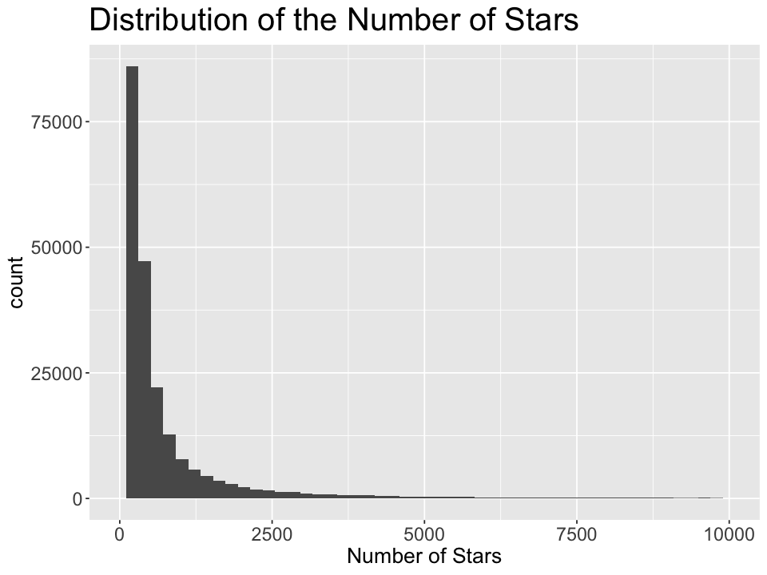

```r
options(repr.plot.width = 8, repr.plot.height = 6)
stars_dist <- git_rep %>%
    ggplot(aes(Stars)) +
    geom_histogram(bins = 50) +
    scale_x_continuous(limits = c(0, 10000)) +
    labs(title = "Distribution of the Number of Stars",
    x = "Number of Stars") +
    theme(
    plot.title = element_text(size = 24),
    axis.title = element_text(size = 16),
    axis.text = element_text(size = 14),
  )
stars_dist
```

The distribution is right-skewed with many extereme values. However, most repositories have the between 0 and 2500 stars. This might leed to poor predictions with the model. We may need to transfrom the response variable using log function. Also, we have a lot of outliers.

#### Explore Relationship Between `Stars` and Other Continous Variables

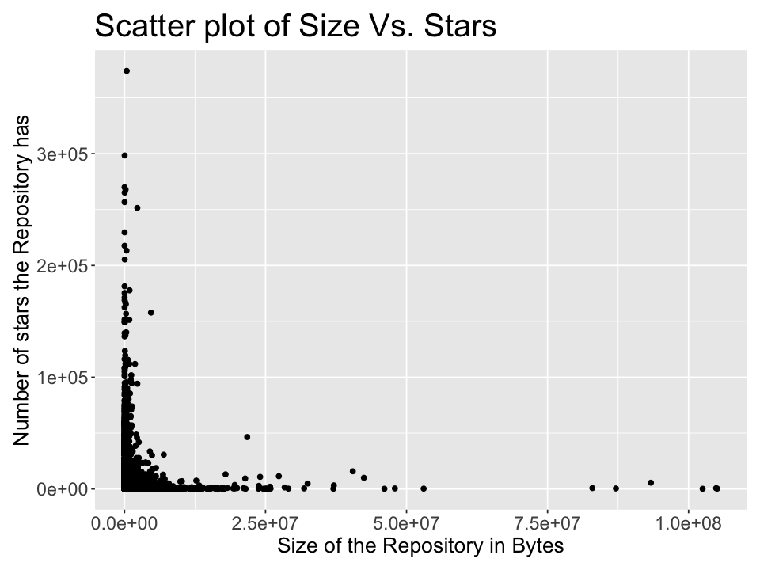

```r
size_stars_plot <- git_rep %>%
    ggplot(aes(x=Size, y = Stars)) +
    geom_point() +
    labs(title = "Scatter plot of Size Vs. Stars",
    x = "Size of the Repository in Bytes",
    y = "Number of stars the Repository has") +
    theme(
    plot.title = element_text(size = 24),
    axis.title = element_text(size = 16),
    axis.text = element_text(size = 14),
    plot.margin = margin(10, 10, 10, 10)
  )
size_stars_plot
```

There doesn't seem to be any relationship between the size of the repository and the number of stars the repository has.

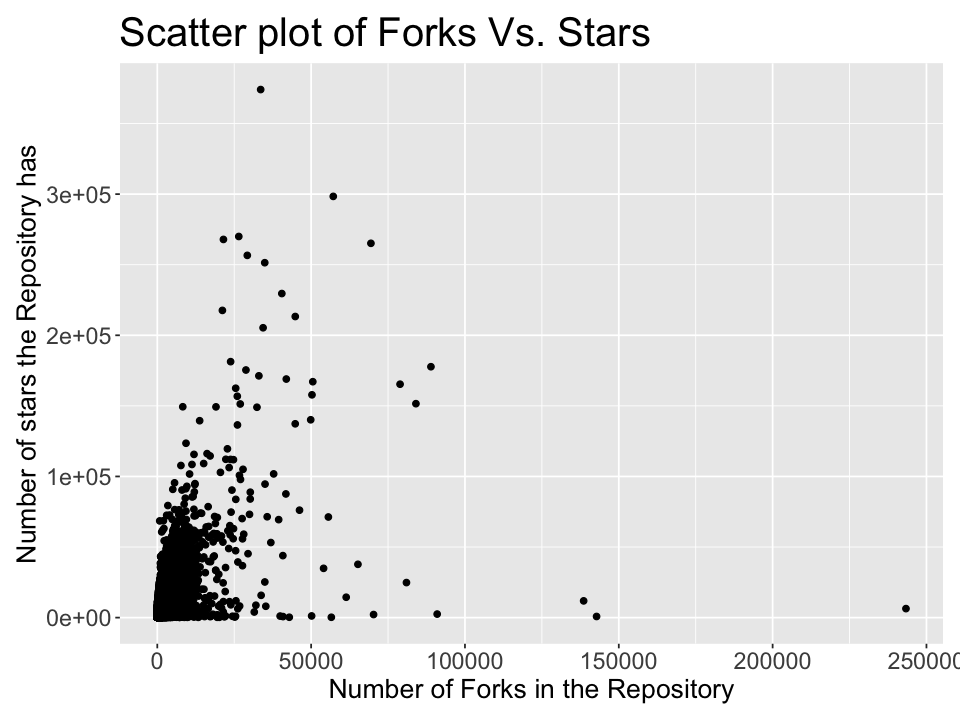

```r
forks_stars_plot <- git_rep %>%
    ggplot(aes(x=Forks, y = Stars)) +
    geom_point() +
    labs(title = "Scatter plot of Forks Vs. Stars",
    x = "Number of Forks in the Repository",
    y = "Number of stars the Repository has") +
    theme(
    plot.title = element_text(size = 24),
    axis.title = element_text(size = 16),
    axis.text = element_text(size = 14),
    plot.margin = margin(10, 10, 10, 10)
  )
forks_stars_plot
```

There is to be a positive linear relationship between the number of forks the repository has and the number of forks it has. We also have outliers in the data.

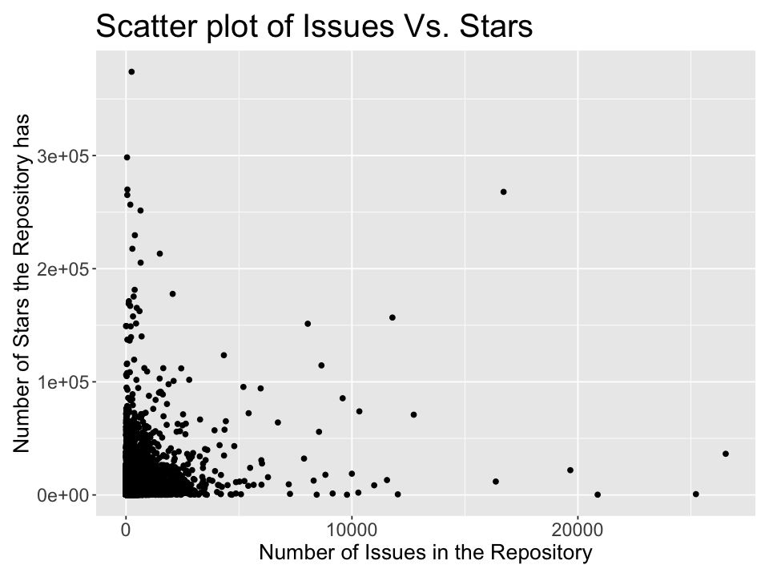

```r
issues_stars_plot <- git_rep %>%
    ggplot(aes(x=Issues, y = Stars)) +
    geom_point() +
    labs(title = "Scatter plot of Issues Vs. Stars",
    x = "Number of Issues in the Repository",
    y = "Number of Stars the Repository has") +
    theme(
    plot.title = element_text(size = 24),
    axis.title = element_text(size = 16),
    axis.text = element_text(size = 14),
    plot.margin = margin(10, 10, 10, 10)
  )
  issues_stars_plot
```

It is not quite clear how the relationship behaves between Stars and Issues. There seem to be a very weak positive linear relationship. Moreover, we seem to have a lot of outliers.

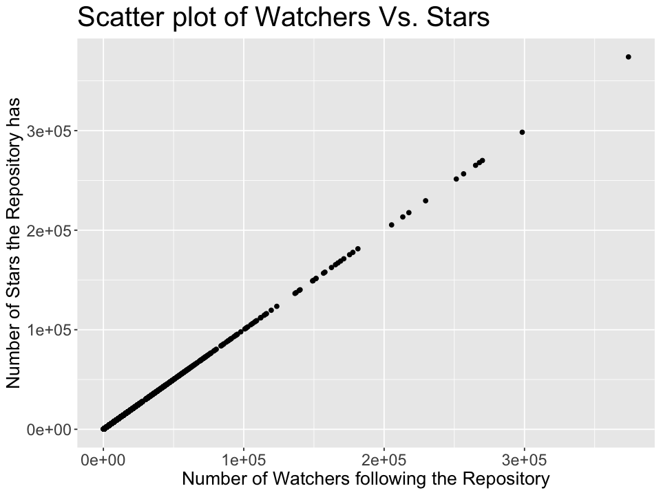

```r
watchers_stars_plot <- git_rep %>%
    ggplot(aes(x = Watchers, y = Stars)) +
    geom_point() +
    labs(title = "Scatter plot of Watchers Vs. Stars",
    x = "Number of Watchers following the Repository",
    y = "Number of Stars the Repository has") +
    theme(
    plot.title = element_text(size = 24),
    axis.title = element_text(size = 16),
    axis.text = element_text(size = 14),
  )
  watchers_stars_plot
```

```r
git_rep %>% select(Stars, Watchers) %>% head(10)
```

A tibble: 10 × 2

| Stars <dbl> | Watchers <dbl> |
| --- | --- |
| 374074 | 374074 |
| 298393 | 298393 |
| 269997 | 269997 |
| 267901 | 267901 |
| 265161 | 265161 |
| 256615 | 256615 |
| 251416 | 251416 |
| 229569 | 229569 |
| 217627 | 217627 |
| 213299 | 213299 |

It seems that the number of Watchers is the same as the Number of Stars a repository has, which explains the perfect line on the plot. This might be because of a mistake with the data collection mechanism. Thus, we cannot use `Watchers` in our model because `Watchers` and `Stars` have a correlation of 1 in this case.

```r
git_rep <- git_rep %>%
    select(-Watchers)
```

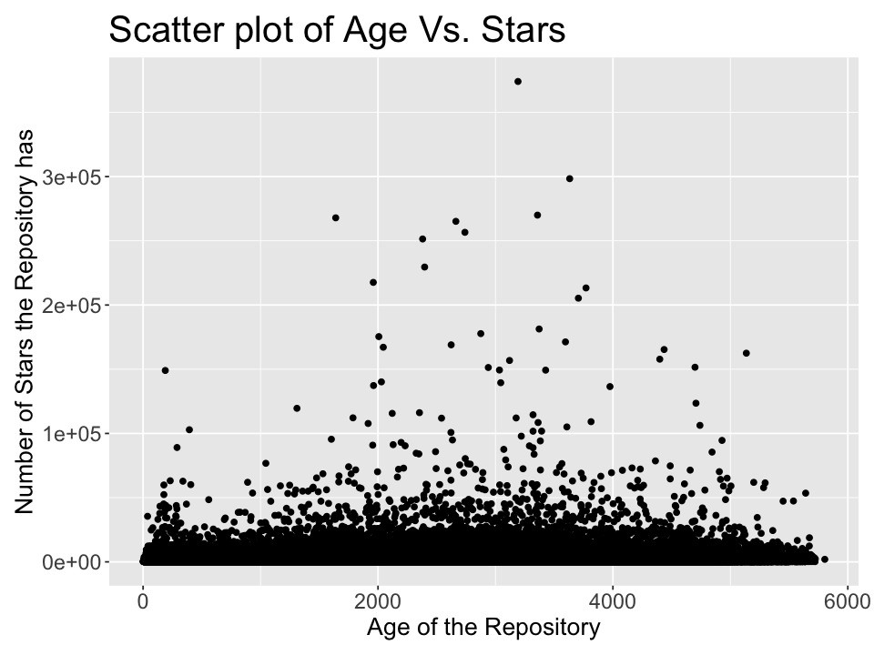

```r
age_stars_plot <- git_rep %>%
    ggplot(aes(x = Age, y = Stars)) +
    geom_point() +
    labs(title = "Scatter plot of Age Vs. Stars",
    x = "Age of the Repository",
    y = "Number of Stars the Repository has") +
    theme(
    plot.title = element_text(size = 24),
    axis.title = element_text(size = 16),
    axis.text = element_text(size = 14),
    plot.margin = margin(10, 10, 10, 10)
  )
  age_stars_plot
```

Unlike expected, there doesn't seem to be any linear relationship between the age of the repository and the number of stars it has.

#### Explore Relationship of the Categorical Variables

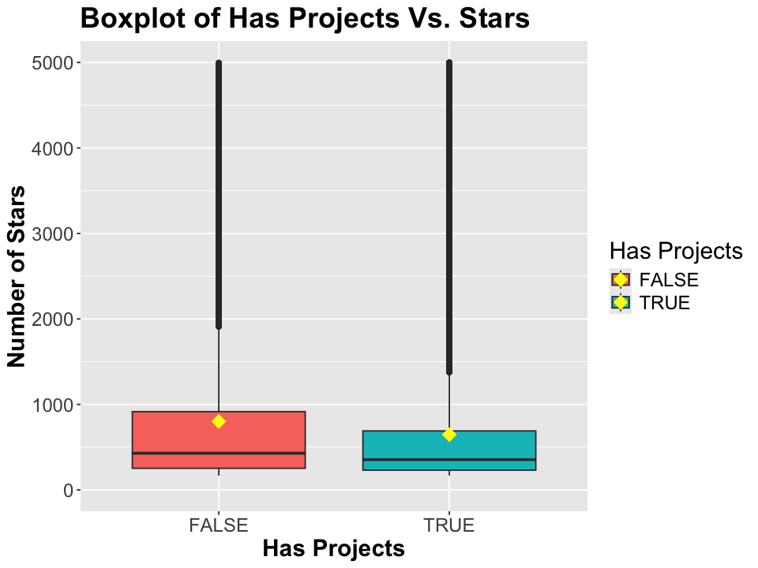

```r
hasProjects_boxplot <- git_rep %>%
    ggplot() +
    geom_boxplot(aes(x = `Has Projects`, y = Stars, fill=`Has Projects`)) +
    labs(title = "Boxplot of Has Projects Vs. Stars",
    x = "Has Projects", y = "Number of Stars") +
    scale_y_continuous(limits = c(0, 5000)) +
    stat_summary(aes(`Has Projects`, Stars, fill = `Has Projects`),
    fun = mean, colour = "yellow", geom = "point",
    shape = 18, size = 5
    ) +
    theme(
    text = element_text(size = 18),
    plot.title = element_text(face = "bold"),
    axis.title = element_text(face = "bold")
    )

hasProjects_boxplot
```

We can see that the mean of stars for a repository that has project is not significantly different than a repository with a project. Additionally, the box plots show that we have a lot of outliers in the data.

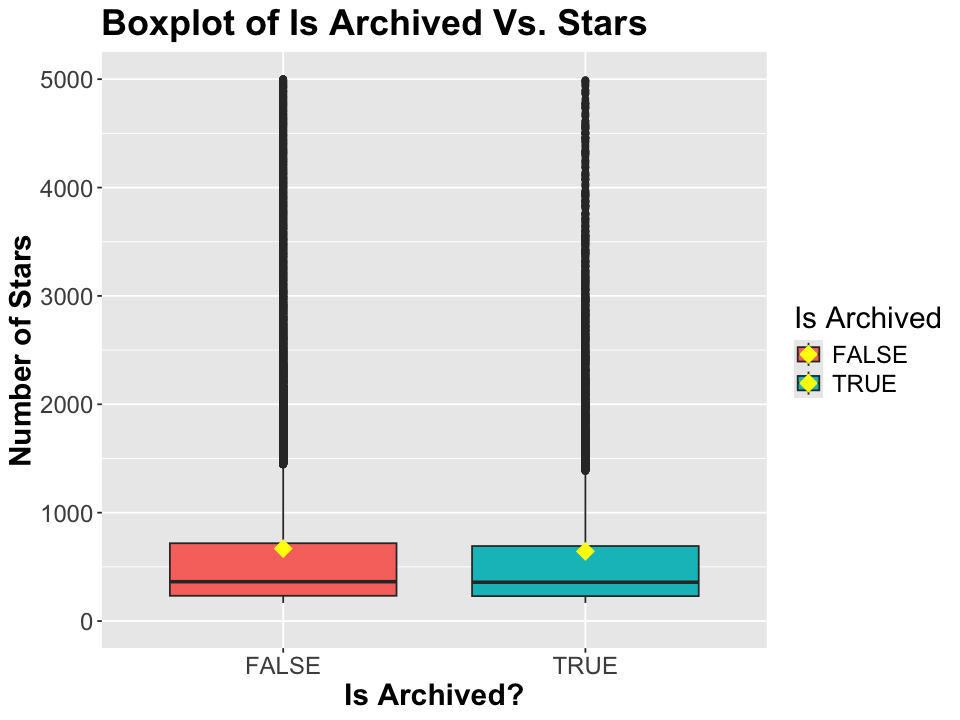

```r
IsFork_boxplot <- git_rep %>%
    ggplot() +
    geom_boxplot(aes(x = `Is Archived`, y = Stars, fill=`Is Archived`)) +
    labs(title = "Boxplot of Is Archived Vs. Stars",
    x = "Is Archived?", y = "Number of Stars") +
    scale_y_continuous(limits = c(0, 5000)) +
    stat_summary(aes(`Is Archived`, Stars, fill = `Is Archived`),
    fun = mean, colour = "yellow", geom = "point",
    shape = 18, size = 5
    ) +
    theme(
    text = element_text(size = 18),
    plot.title = element_text(face = "bold"),
    axis.title = element_text(face = "bold")
    )

IsFork_boxplot
```

Again, there isn't any noticeable difference in the box plot of stars between archived and non-archived repositories.

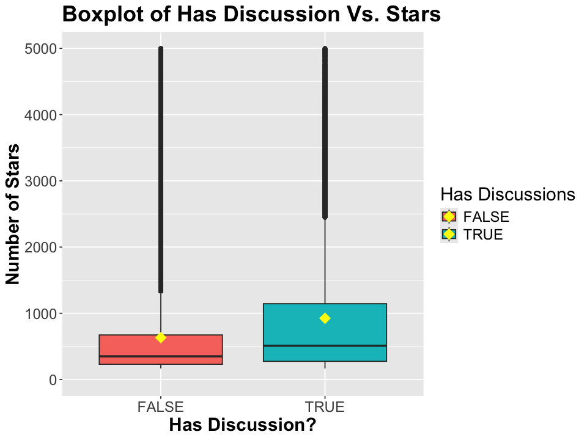

```r
discussion_boxplot <- git_rep %>%
    ggplot() +
    geom_boxplot(aes(x = `Has Discussions`, y = Stars, fill=`Has Discussions`)) +
    labs(title = "Boxplot of Has Discussion Vs. Stars",
    x = "Has Discussion?", y = "Number of Stars") +
    scale_y_continuous(limits = c(0, 5000)) +
    stat_summary(aes(`Has Discussions`, Stars, fill = `Has Discussions`),
    fun = mean, colour = "yellow", geom = "point",
    shape = 18, size = 5
    ) +
    theme(
    text = element_text(size = 18),
    plot.title = element_text(face = "bold"),
    axis.title = element_text(face = "bold")
    )

discussion_boxplot
```

The mean number of stars seem to differ between repositories with discussions and without discussions however, there is a lot of overlapping between the two categories. Thus, we need further statistical tests to draw a conclusion.

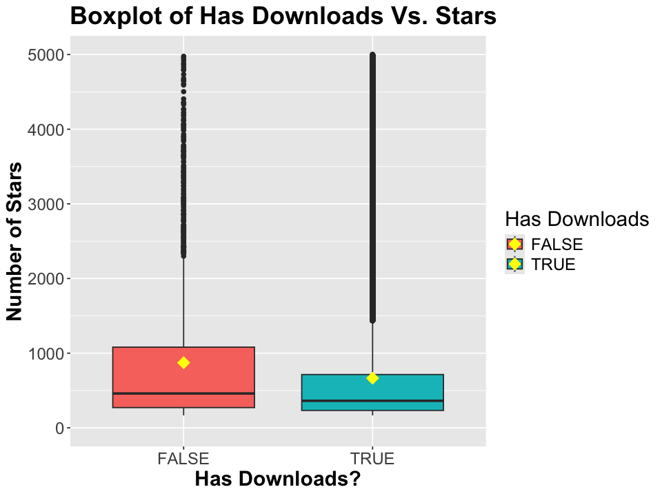

```r
discussion_boxplot <- git_rep %>%
    ggplot() +
    geom_boxplot(aes(x = `Has Downloads`, y = Stars, fill=`Has Downloads`)) +
    labs(title = "Boxplot of Has Downloads Vs. Stars",
    x = "Has Downloads?", y = "Number of Stars") +
    scale_y_continuous(limits = c(0, 5000)) +
    stat_summary(aes(`Has Downloads`, Stars, fill = `Has Downloads`),
    fun = mean, colour = "yellow", geom = "point",
    shape = 18, size = 5
    ) +
    theme(
    text = element_text(size = 18),
    plot.title = element_text(face = "bold"),
    axis.title = element_text(face = "bold")
    )

discussion_boxplot
```

The boxplots are similar to eachother except that there is more variety in repositories with no downloads.

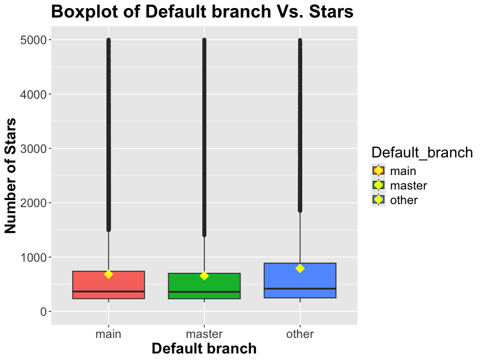

```r
default_branch_boxplot <- git_rep %>%
    ggplot() +
    geom_boxplot(aes(x = `Default_branch`, y = Stars, fill=`Default_branch`)) +
    labs(title = "Boxplot of Default branch Vs. Stars",
    x = "Default branch", y = "Number of Stars") +
    scale_y_continuous(limits = c(0, 5000)) +
    stat_summary(aes(`Default_branch`, Stars, fill = `Default_branch`),
    fun = mean, colour = "yellow", geom = "point",
    shape = 18, size = 5
    ) +
    theme(
    text = element_text(size = 18),
    plot.title = element_text(face = "bold"),
    axis.title = element_text(face = "bold")
    )

default_branch_boxplot
```

The box plots for the three gategories are very similar, except that the other category has more variety.

In conclusion, the `Stars` variable is highly right-skewed with numerous outliers, we may need to apply log transformation to the response variable. Moreover, the covariates we examined don't seem to show that they will be significant in the model, except the `Forks` variable. However, we will still test all of them and see which ones are significant.

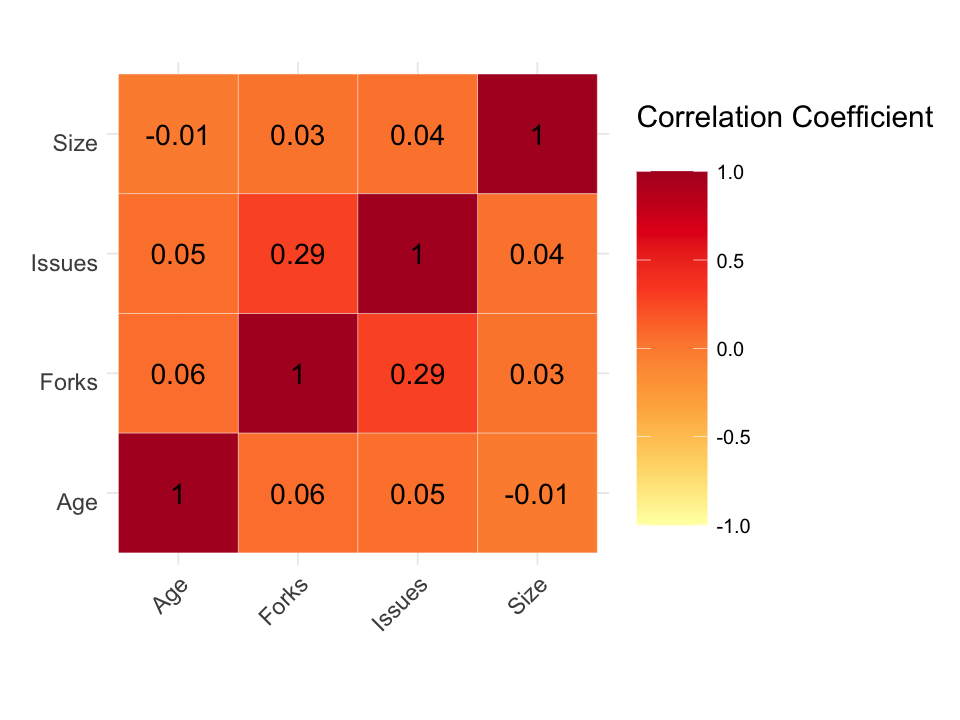

```r
cor_matrix <- git_rep %>%
    select_if(is.numeric) %>%
   select(- Stars) %>%
   cor() %>%
   as_tibble(rownames = 'var1') %>%
   pivot_longer(-var1, names_to = "var2", values_to = "corr")


plot_cor_matrix <- cor_matrix %>%
    ggplot(aes(var1, var2)) +
    geom_tile(aes(fill = corr), color = "white") +
    scale_fill_distiller("Correlation Coefficient \n",
      palette =  "YlOrRd",
      direction = 1,
      limits = c(-1,1)
    ) +
    labs(x = "", y = "") +
    theme_minimal() +
    theme(
        axis.text.x = element_text(angle = 45, vjust = 1, size = 14, hjust = 1),
        axis.text.y = element_text(vjust = 1, size = 14, hjust = 1),
        legend.title = element_text(size = 18),
        legend.text = element_text(size = 12),
        legend.key.size = unit(1.5, "cm")
    ) +
    coord_fixed() +
    geom_text(aes(var1, var2, label = round(corr, 2)), color = "black", size = 6)

plot_cor_matrix
```

```r
colSums(is.na(git_rep))
```

**Size**

0

**Stars**

0

**Forks**

0

**Issues**

0

**Has Issues**

0

**Has Projects**

0

**Has Downloads**

0

**Has Wiki**

0

**Has Pages**

0

**Has Discussions**

0

**Is Fork**

0

**Is Archived**

0

**Is Template**

0

**Age**

0

**Default_branch**

0

It seems that the number of isssues is correlated with the number of forks.

# Methods and Plan & Computational Code and Output(individual assignment 2)

## Methods and Plan

We will develop two plans for this project, each addressing one of the research questions. The first step of each plan involves splitting the data into training and testing sets. All model training will be conducted on the training set, while the testing set will only be used in the final evaluation stages to ensure unbiased and accurate results.

To investigate the relationship between the number of stars a repository has and its size, number of forks, and number of issues, we will fit a linear regression model. In this model, the number of stars will serve as the response variable, with size, forks, and issues as explanatory variables. We will evaluate the p-values of the coefficients and the $R^2$ value to assess the appropriateness of a linear model. This method assumes constant residual variance (homoscedasticity), independent and normally distributed residuals, and no multicollinearity among predictors. If needed, we may apply log transformations to improve model fit. However, this approach could be limited by the presence of outliers or skewed distributions in the numerical variables, which may reduce accuracy.

For the second research question—identifying significant predictors of the number of stars—we will use variable selection algorithms. Forward selection and backward selection will be applied to find models with the highest adjusted $R^2$, lowest root mean squared error (RMSE), and best $C_p$. The final model will be chosen by comparing the best results from both methods. The assumptions for this approach are the same as those in the first method, with the additional premise that a simpler model with fewer predictors is preferable. However, the process may be limited by the inherent design of the algorithms, which might overlook optimal combinations of predictors where the best combination of variables may not be tested by neither of the two algorithms.

## Implementation of a proposed model

```r
head(git_rep)
```

A tibble: 6 × 15

| Size <dbl> | Stars <dbl> | Forks <dbl> | Issues <dbl> | Has Issues <lgl> | Has Projects <lgl> | Has Downloads <lgl> | Has Wiki <lgl> | Has Pages <lgl> | Has Discussions <lgl> | Is Fork <lgl> | Is Archived <lgl> | Is Template <lgl> | Age <int> | Default_branch <chr> |
| --- | --- | --- | --- | --- | --- | --- | --- | --- | --- | --- | --- | --- | --- | --- |
| 387451 | 374074 | 33599 | 248 | TRUE | TRUE | TRUE | FALSE | TRUE | FALSE | FALSE | FALSE | FALSE | 3192 | main |
| 17087 | 298393 | 57194 | 46 | TRUE | FALSE | TRUE | FALSE | TRUE | FALSE | FALSE | FALSE | FALSE | 3632 | main |
| 1441 | 269997 | 26485 | 61 | TRUE | FALSE | TRUE | FALSE | TRUE | FALSE | FALSE | FALSE | FALSE | 3358 | main |
| 187799 | 267901 | 21497 | 16712 | FALSE | FALSE | TRUE | FALSE | FALSE | FALSE | FALSE | TRUE | FALSE | 1640 | master |
| 20998 | 265161 | 69434 | 56 | TRUE | FALSE | TRUE | FALSE | FALSE | FALSE | FALSE | FALSE | FALSE | 2663 | main |
| 5088 | 256615 | 29254 | 191 | TRUE | FALSE | TRUE | FALSE | FALSE | FALSE | FALSE | FALSE | FALSE | 2740 | master |

Write a computation code to implement the method proposed in the previous assignment (or suggested in the interview) and use a visualization or table to report the results. In 3 or 4 sentences give a brief interpretation of the results. If needed, comment on any unexpected result or potential problems with the analysis, and possible ways to address issues encountered. If results are as expected, explain how they address the question of interest.

1. Add the new content at the end of your existing notebook containing the data description, question, visualization and plan. We won't regrade those but they provide useful context.
2. Name the new section "Implementation of a proposed model"
3. Write a computational code to implement *one* of the method proposed in the previous assignment (or suggested in the interview).
4. Use *only one* visualization or table to report the results.
5. In 3 or 4 sentences give a brief interpretation of the results. If needed, comment on any unexpected result or potential problems with the analysis, and possible ways to address issues encountered. If results are as expected, explain how they address the question of interest. **Do not exceed the 4 sentences limit**.

```r
git_split <- initial_split(data = git_rep, prop = 0.7)
git_train <- training(git_split)
git_test <- testing(git_split)
```

```r
stars_numeric_lm <- lm(Stars ~ Size + Issues + Forks, data = git_train)
stars_numeric_lm_summary <- summary(stars_numeric_lm)
stars_numeric_lm_summary
```

```
Call:
lm(formula = Stars ~ Size + Issues + Forks, data = git_train)

Residuals:
    Min      1Q  Median      3Q     Max
-229333    -428    -316     -89  203131

Coefficients:
              Estimate Std. Error t value Pr(>|t|)
(Intercept)  4.786e+02  7.573e+00  63.199   <2e-16 ***
Size        -1.104e-05  9.891e-06  -1.116    0.264
Issues       1.443e+00  4.002e-02  36.067   <2e-16 ***
Forks        2.503e+00  7.315e-03 342.217   <2e-16 ***
---
Signif. codes:  0 ‘***’ 0.001 ‘**’ 0.01 ‘*’ 0.05 ‘.’ 0.1 ‘ ’ 1

Residual standard error: 2836 on 150516 degrees of freedom
Multiple R-squared:  0.4748,	Adjusted R-squared:  0.4748
F-statistic: 4.536e+04 on 3 and 150516 DF,  p-value: < 2.2e-16
```

```r
stars_numeric_lm_results <- tidy(stars_numeric_lm, conf.int = TRUE)
stars_numeric_lm_results
```

A tibble: 4 × 7

| term <chr> | estimate <dbl> | std.error <dbl> | statistic <dbl> | p.value <dbl> | conf.low <dbl> | conf.high <dbl> |
| --- | --- | --- | --- | --- | --- | --- |
| (Intercept) | 4.786310e+02 | 7.573387e+00 | 63.19907 | 0.000000e+00 | 4.637873e+02 | 4.934747e+02 |
| Size | -1.104285e-05 | 9.891215e-06 | -1.11643 | 2.642399e-01 | -3.042943e-05 | 8.343732e-06 |
| Issues | 1.443481e+00 | 4.002170e-02 | 36.06745 | 1.206743e-283 | 1.365039e+00 | 1.521923e+00 |
| Forks | 2.503294e+00 | 7.314920e-03 | 342.21749 | 0.000000e+00 | 2.488956e+00 | 2.517631e+00 |

At 5% significance level, all numerical variables in the `stars_numeric_lm` model are significant, except `Size`. Also, the three variables (`Size`, `Issues`, and `Forks`) explain 0.47 of the variation in `Stars`.

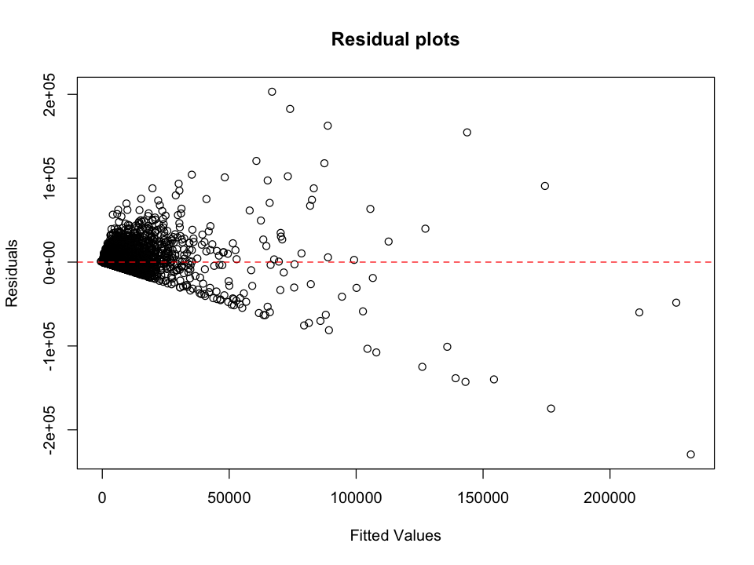

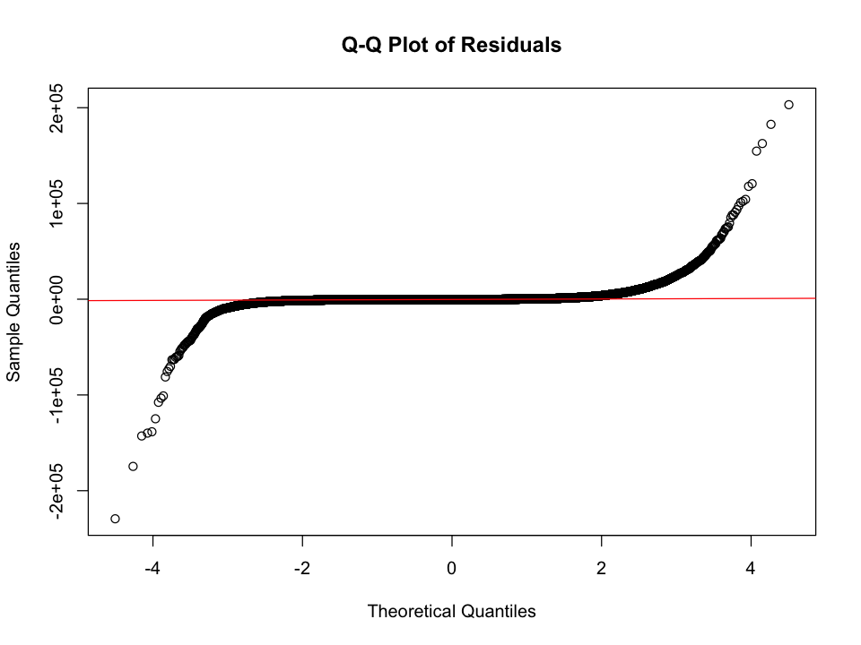

```r
# Residuals plot
plot(x = stars_numeric_lm$fitted.values, y = stars_numeric_lm$residuals,
    main = "Residual plots",
    xlab = "Fitted Values",
    ylab = "Residuals")
abline(h = 0, col = "red", lty = 2)

## QQ-Plot
qqnorm(stars_numeric_lm$residuals, main = "Q-Q Plot of Residuals")
qqline(stars_numeric_lm$residuals, col = "red")
```

The residuals plot shows a clear funnel shape which indicates heteroscedasticity. We can tackle this by applying a log transformation to `Stars`. Also, The QQ-plot shows that residuals are not normally distributed.

```r
r_sqr <- function(y_actual, y_predicted) {
    SS_residuals <- sum((y_actual - y_predicted)^2)
    SS_total <- sum((y_actual - mean(y_actual))^2)
    R2 <- 1 - (SS_residuals / SS_total)
    return(R2)
}
```

```r
train_preds <- predict(stars_numeric_lm, newdata = git_train)
y_train <- git_train$Stars
test_preds <- predict(stars_numeric_lm, newdata= git_test)
y_test <- git_test$Stars
stars_numeric_lm_metrics <- data.frame(
    model = "Raw linear model",
    data = c("training", "testing"),
    rmse = c(rmse(y_train, train_preds), rmse(y_test,test_preds)),
    mae = c(mae(y_train, train_preds), mae(y_test, test_preds)),
    r_sqr = c(r_sqr(y_train, train_preds), r_sqr(y_test, test_preds))
)

stars_numeric_lm_metrics
```

A data.frame: 2 × 5

| model <chr> | data <chr> | rmse <dbl> | mae <dbl> | r_sqr <dbl> |
| --- | --- | --- | --- | --- |
| Raw linear model | training | 2835.630 | 748.8914 | 0.47480796 |
| Raw linear model | testing | 4264.339 | 763.4851 | -0.04472969 |

The model performs moderately well on the training data, but its performance on the testing data is poor. The negative $R^2$ indicates that the model's predictions are worse than simply predicting the mean value of the response variable. This poor performance could be caused by the presence of numerous outliers in the data and the highly skewed distribution of the response variable. In conclusion, a linear regression model appears to be an inappropriate choice for modeling the relationship between the number of stars and the repository's size, number of issues, and number of forks.